# Analysis of income by college major

# Dependencies

First we load the dataset from the collegeIncome package. Next we load the broom package for tidier display of regression output and the dplyr package for working with data frames.

```r
library(collegeIncome)
data(college)
library(broom)
library(dplyr)
```

# Exploratory data analysis

Let’s take a look at the data to get acquainted with the contents.

```r
head(college)
```

```
##   rank major_code                                     major major_category
## 1    1       2419                     Petroleum Engineering    Engineering
## 2    2       2416            Mining And Mineral Engineering    Engineering
## 3    3       2415                 Metallurgical Engineering    Engineering
## 4    4       2417 Naval Architecture And Marine Engineering    Engineering
## 5    5       2405                      Chemical Engineering    Engineering
## 6    6       2418                       Nuclear Engineering    Engineering
##   total sample_size perc_women p25th median  p75th   perc_men perc_employed
## 1  2339          36  0.9109326 25000  40000  50000 0.08906743     0.9115044
## 2   756           7  0.5154064 26000  37000  40000 0.48459355     0.7980501
## 3   856           3  0.5942076 26700  45000  60000 0.40579235     0.7871943
## 4  1258          16  0.6521298 26000  35000  45000 0.34787018     0.8465608
## 5 32260         289  0.4179248 31500  62000 109000 0.58207520     0.8515625
## 6  2573          17  0.4305368 23000  44700  50000 0.56946324     0.8474507
##   perc_employed_fulltime perc_employed_parttime
```

[output cut: 20 more lines]

```r
summary(college)
```

```
##       rank       major_code      major           major_category
##  Min.   :  1   Min.   :1100   Length:173         Length:173
##  1st Qu.: 44   1st Qu.:2403   Class :character   Class :character
##  Median : 87   Median :3608   Mode  :character   Mode  :character
##  Mean   : 87   Mean   :3880
##  3rd Qu.:130   3rd Qu.:5503
##  Max.   :173   Max.   :6403
##
##      total         sample_size       perc_women         p25th
##  Min.   :   124   Min.   :   2.0   Min.   :0.0000   Min.   :18500
##  1st Qu.:  4361   1st Qu.:  39.0   1st Qu.:0.3397   1st Qu.:24000
##  Median : 15058   Median : 130.0   Median :0.5357   Median :27000
##  Mean   : 39168   Mean   : 356.1   Mean   :0.5226   Mean   :29501
##  3rd Qu.: 38844   3rd Qu.: 338.0   3rd Qu.:0.7020   3rd Qu.:33000
##  Max.   :393735   Max.   :4212.0   Max.   :0.9690   Max.   :95000
##
##      median           p75th           perc_men       perc_employed
##  Min.   : 22000   Min.   : 22000   Min.   :0.03105   Min.   :0.0000
##  1st Qu.: 33000   1st Qu.: 42000   1st Qu.:0.29798   1st Qu.:0.7477
##  Median : 36000   Median : 47000   Median :0.46429   Median :0.8028
##  Mean   : 40151   Mean   : 51494   Mean   :0.47745   Mean   :0.7886
##  3rd Qu.: 45000   3rd Qu.: 60000   3rd Qu.:0.66033   3rd Qu.:0.8410
##  Max.   :110000   Max.   :125000   Max.   :1.00000   Max.   :0.9562
##
##  perc_employed_fulltime perc_employed_parttime perc_employed_fulltime_yearround
##  Min.   :0.5743         Min.   :0.0000         Min.   :0.5857
##  1st Qu.:0.7741         1st Qu.:0.2090         1st Qu.:0.7009
##  Median :0.8319         Median :0.2862         Median :0.7484
##  Mean   :   Inf         Mean   :0.2874         Mean   :0.7476
##  3rd Qu.:0.8974         3rd Qu.:0.3623         3rd Qu.:0.7896
##  Max.   :   Inf         Max.   :0.5518         Max.   :1.0000
##                         NA's   :1
##  perc_unemployed   perc_college_jobs perc_non_college_jobs perc_low_wage_jobs
##  Min.   :0.04383   Min.   :0.0633    Min.   :0.08278       Min.   :0.00000
##  1st Qu.:0.15899   1st Qu.:0.2974    1st Qu.:0.27995       1st Qu.:0.06957
##  Median :0.19723   Median :0.4160    Median :0.42020       Median :0.10857
##  Mean   :0.21140   Mean   :0.4478    Mean   :0.41498       Mean   :0.11481
##  3rd Qu.:0.25229   3rd Qu.:0.6170    3rd Qu.:0.52756       3rd Qu.:0.15353
##  Max.   :1.00000   Max.   :0.8383    Max.   :0.85364       Max.   :0.36566
##                    NA's   :1         NA's   :1             NA's   :1
```

What are the different categories of college majors?

```r
table(college$major_category)
```

```
##
##     Agriculture & Natural Resources                                Arts
##                                  10                                   8
##              Biology & Life Science                            Business
##                                  14                                  13
##         Communications & Journalism             Computers & Mathematics
##                                   4                                  11
##                           Education                         Engineering
##                                  16                                  29
##                              Health           Humanities & Liberal Arts
##                                  12                                  15
## Industrial Arts & Consumer Services                   Interdisciplinary
##                                   7                                   1
##                 Law & Public Policy                   Physical Sciences
##                                   5                                  10
##            Psychology & Social Work                      Social Science
##                                   9                                   9
```

Only one major falls into the “Interdisciplinary” category. We certainly cannot estimate an effect for this category, so we will remove it.

```r
college <- college %>%
filter(major_category != "Interdisciplinary")
table(college$major_category)
```

```
##
##     Agriculture & Natural Resources                                Arts
##                                  10                                   8
##              Biology & Life Science                            Business
##                                  14                                  13
##         Communications & Journalism             Computers & Mathematics
##                                   4                                  11
##                           Education                         Engineering
##                                  16                                  29
##                              Health           Humanities & Liberal Arts
##                                  12                                  15
## Industrial Arts & Consumer Services                 Law & Public Policy
##                                   7                                   5
##                   Physical Sciences            Psychology & Social Work
##                                  10                                   9
##                      Social Science
##                                   9
```

Median income in a category is a useful measure because it indicates an income level that is typical in that category. Later we will used median income as our outcome measure in linear regression, but it is useful to look at plots of how the three different income measures (25th, 50th, and 75th percentile of income among those reporting income in the survey) vary across categories.

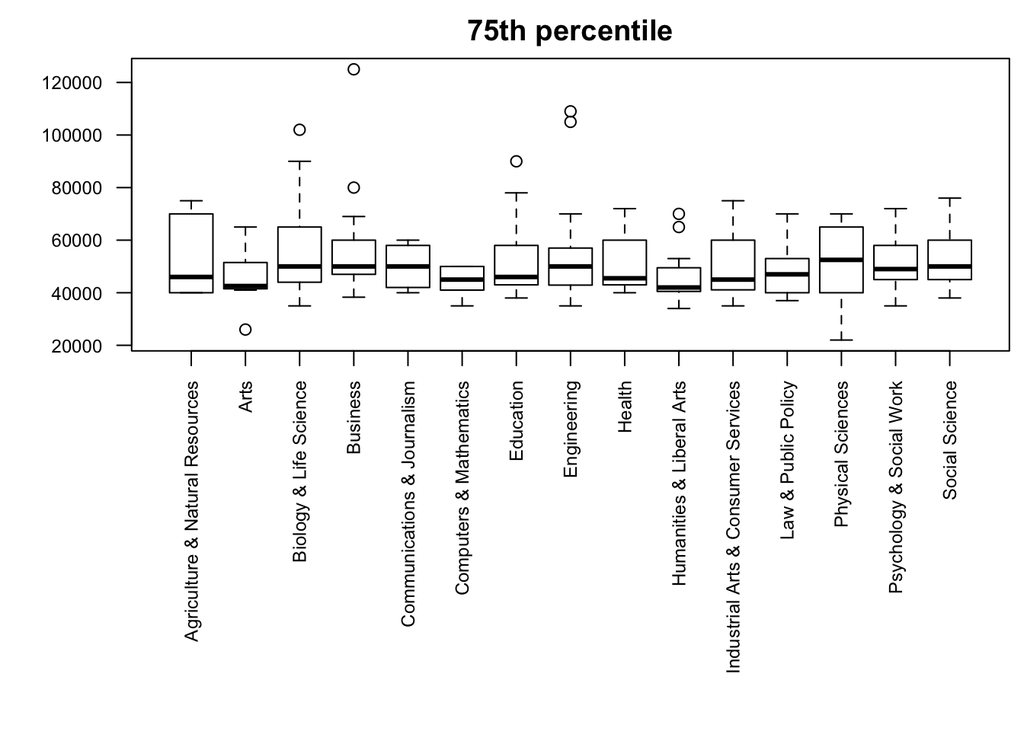

```r
par(mar = c(13,4.5,2,0.5))
boxplot(p75th ~ major_category, data = college, main = "75th percentile", las = 2, cex.axis = 0.75)
```

25th percentile

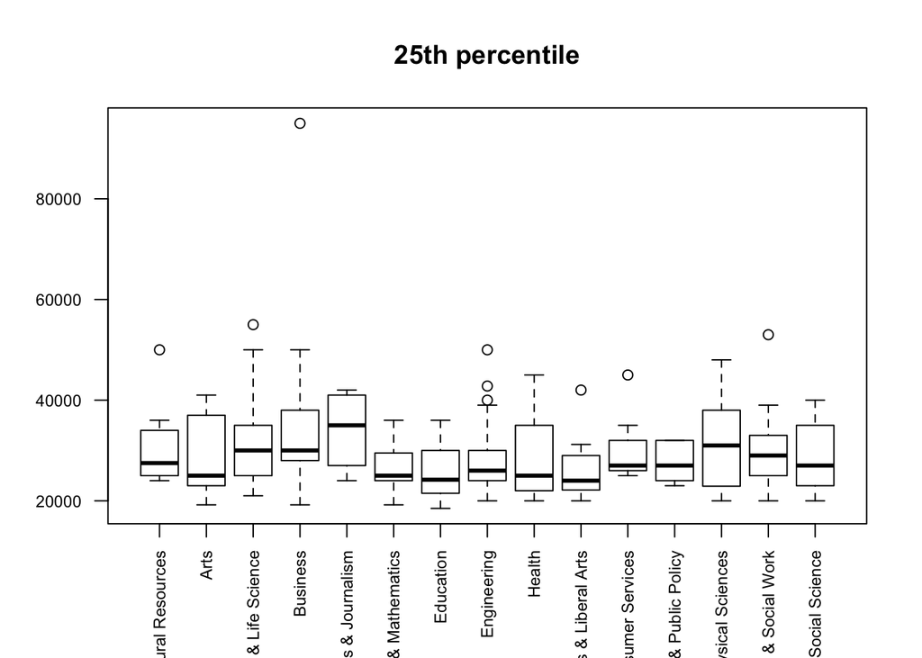

```r
boxplot(p25th ~ major_category, data = college, main = "25th percentile", las = 2, cex.axis = 0.75)
```

50th percentile

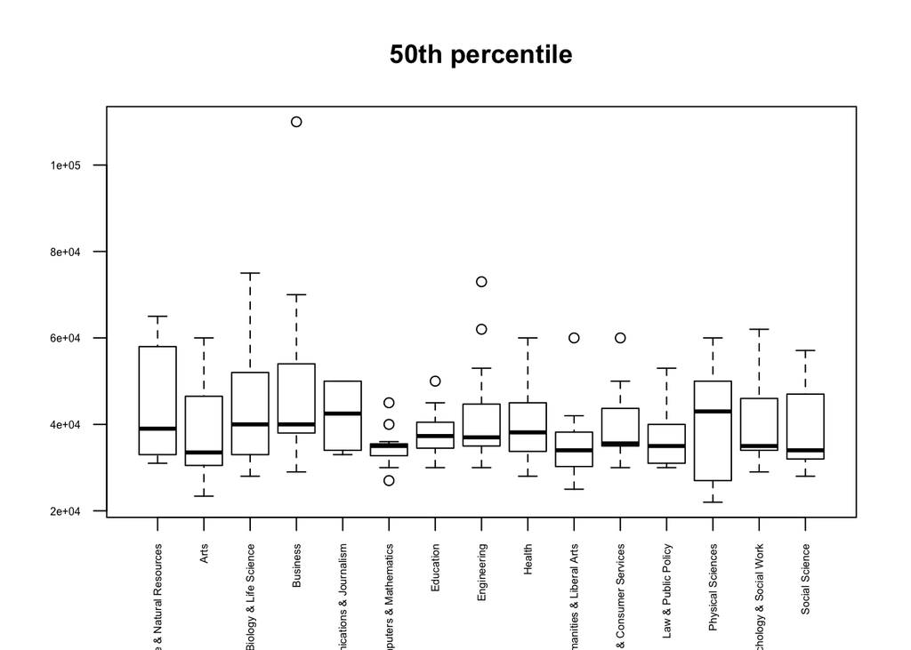

```r
boxplot(median ~ major_category, data = college, main = "50th percentile", las = 2, cex.axis = 0.50)
```

There doesn’t seem to be considerable variation across categories for either of these three measures, so we will stick with using the median as our outcome measure.

# Linear regression

Because the income information is defined to pertain to full-time, year-round workers, we will look at other characteristics: namely, gender effects and effects related to type of job (jobs requiring a college degree and jobs that are low-wage service positions). We can fit this linear model and view inference results with the following commands:

```r
lmfit <- lm(median ~ major_category+perc_women+perc_college_jobs+perc_low_wage_jobs, data = college)
summary(lmfit)
```

```
##
## Call:
## lm(formula = median ~ major_category + perc_women + perc_college_jobs +
##     perc_low_wage_jobs, data = college)
##
## Residuals:
##    Min     1Q Median     3Q    Max
## -21088  -6917  -3211   5965  56932
##
## Coefficients:
##                                                   Estimate Std. Error t value
## (Intercept)                                        49491.3     5647.2   8.764
## major_categoryArts                                 -5429.2     5435.1  -0.999
## major_categoryBiology & Life Science                 707.2     4772.0   0.148
## major_categoryBusiness                              5540.4     4846.5   1.143
## major_categoryCommunications & Journalism          -2776.6     6761.1  -0.411
## major_categoryComputers & Mathematics              -9607.2     5129.6  -1.873
## major_categoryEducation                            -5140.6     4591.3  -1.120
## major_categoryEngineering                          -2931.4     4185.3  -0.700
## major_categoryHealth                               -3700.9     4880.2  -0.758
## major_categoryHumanities & Liberal Arts            -9022.7     4711.1  -1.915
## major_categoryIndustrial Arts & Consumer Services  -2731.0     5604.6  -0.487
## major_categoryLaw & Public Policy                  -5612.6     6374.9  -0.880
## major_categoryPhysical Sciences                    -3268.4     5109.4  -0.640
## major_categoryPsychology & Social Work             -5102.7     5340.0  -0.956
## major_categorySocial Science                       -3059.1     5287.2  -0.579
## perc_women                                         -5011.5     3958.1  -1.266
## perc_college_jobs                                  -7841.4     5283.5  -1.484
## perc_low_wage_jobs                                  2108.6    16018.8   0.132
##                                                   Pr(>|t|)
## (Intercept)                                       3.36e-15 ***
## major_categoryArts                                  0.3194
## major_categoryBiology & Life Science                0.8824
## major_categoryBusiness                              0.2548
## major_categoryCommunications & Journalism           0.6819
## major_categoryComputers & Mathematics               0.0630 .
## major_categoryEducation                             0.2646
## major_categoryEngineering                           0.4847
## major_categoryHealth                                0.4494
## major_categoryHumanities & Liberal Arts             0.0573 .
## major_categoryIndustrial Arts & Consumer Services   0.6268
## major_categoryLaw & Public Policy                   0.3800
## major_categoryPhysical Sciences                     0.5233
## major_categoryPsychology & Social Work              0.3408
## major_categorySocial Science                        0.5637
## perc_women                                          0.2074
## perc_college_jobs                                   0.1398
## perc_low_wage_jobs                                  0.8954
## ---
## Signif. codes:  0 '***' 0.001 '**' 0.01 '*' 0.05 '.' 0.1 ' ' 1
##
## Residual standard error: 11330 on 153 degrees of freedom
##   (1 observation deleted due to missingness)
## Multiple R-squared:  0.1236, Adjusted R-squared:  0.02627
## F-statistic:  1.27 on 17 and 153 DF,  p-value: 0.2191
```

Holding constant gender distributions and skill category distributions, we don’t see much effect of major category (reference category is Agriculture & Natural Resources - how can we tell?). In particular, it is important to consider the multiple hypothesis testing issue here as we have many different major categories. Considering this, we really don’t see much of a category effect on income. Further the F-statistic results at the bottom do not suggest that the variables included have an impact on median income.

We can check if regression assumptions are met with diagnostic plotting:

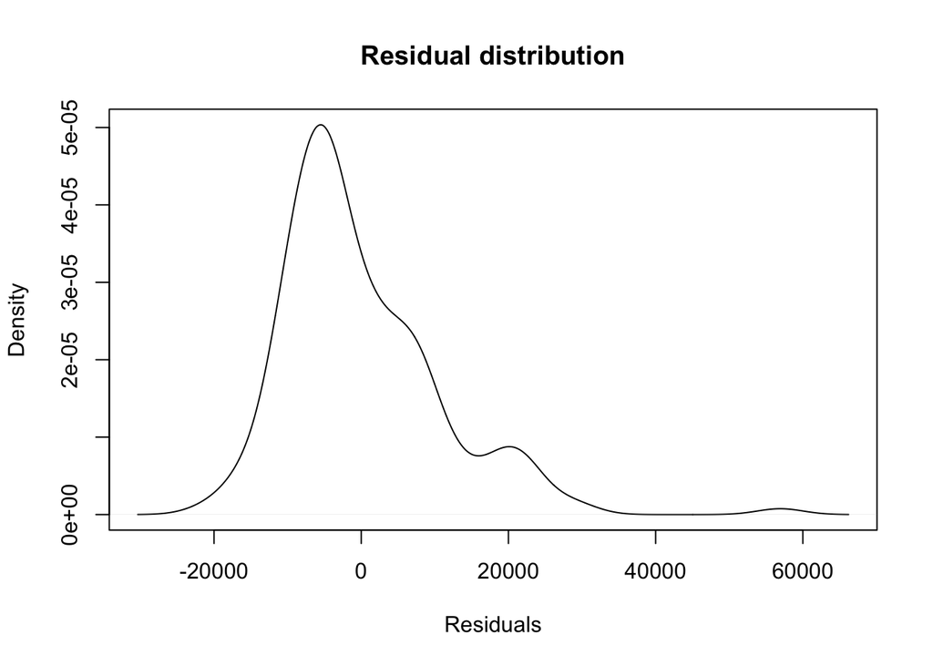

```r
resid <- residuals(lmfit)
fitted <- fitted.values(lmfit)
plot(density(resid), xlab = "Residuals", ylab = "Density", main = "Residual distribution")
```

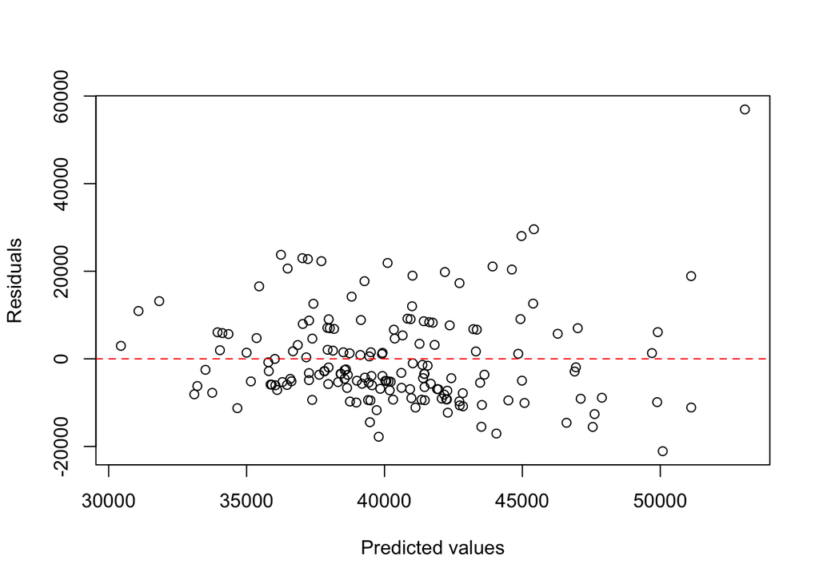

```r
plot(fitted, resid, xlab = "Predicted values", ylab = "Residuals")
abline(h = 0, col = "red", lty = "dashed")
```

Normality assumptions don’t seem far off (approximately), and heteroskedasticity doesn’t seem to be an issue. Perhaps there is one outlier, but that is unlikely to have changed the overall results too much. Overall there doesn’t seem to be an effect of college major category on median income in this study.

FYI: A slightly neater display of the inference results for the coefficients can be obtained with the tidy function in the broom package:

```r
tidy(lmfit)
```

```
## # A tibble: 18 x 5
##    term                                    estimate std.error statistic  p.value
##    <chr>                                      <dbl>     <dbl>     <dbl>    <dbl>
##  1 (Intercept)                               49491.     5647.     8.76  3.36e-15
##  2 major_categoryArts                        -5429.     5435.    -0.999 3.19e- 1
##  3 major_categoryBiology & Life Science        707.     4772.     0.148 8.82e- 1
##  4 major_categoryBusiness                     5540.     4847.     1.14  2.55e- 1
##  5 major_categoryCommunications & Journal…   -2777.     6761.    -0.411 6.82e- 1
##  6 major_categoryComputers & Mathematics     -9607.     5130.    -1.87  6.30e- 2
##  7 major_categoryEducation                   -5141.     4591.    -1.12  2.65e- 1
##  8 major_categoryEngineering                 -2931.     4185.    -0.700 4.85e- 1
##  9 major_categoryHealth                      -3701.     4880.    -0.758 4.49e- 1
## 10 major_categoryHumanities & Liberal Arts   -9023.     4711.    -1.92  5.73e- 2
## 11 major_categoryIndustrial Arts & Consum…   -2731.     5605.    -0.487 6.27e- 1
## 12 major_categoryLaw & Public Policy         -5613.     6375.    -0.880 3.80e- 1
## 13 major_categoryPhysical Sciences           -3268.     5109.    -0.640 5.23e- 1
## 14 major_categoryPsychology & Social Work    -5103.     5340.    -0.956 3.41e- 1
## 15 major_categorySocial Science              -3059.     5287.    -0.579 5.64e- 1
## 16 perc_women                                -5012.     3958.    -1.27  2.07e- 1
## 17 perc_college_jobs                         -7841.     5283.    -1.48  1.40e- 1
## 18 perc_low_wage_jobs                         2109.    16019.     0.132 8.95e- 1
```